# rswat.maker and the Lamar River

Dean Koch July 24, 2023

- Introduction
  - Getting started
  - The whole workflow
- Data
  - 1. NHDPlus catchment model (`get_catch`)
  - 2. NWIS gage data (`get_nwis`)
  - 3. DEM (`get_dem`)
  - 4. NLCD land use (`get_land`)
  - 5. STATSGO2/SSURGO soil (`get_soil`)
- Processing
  - 6. Subcatchments (`get_split`)
    - Splitting at gages
    - Snapping and overlap
  - 7. QSWAT+ inputs (`save_qswat`)
  - 8. QSWAT+ setup (`run_qswat`)
    - Automation with `run_qswat`
    - QSWAT+ results
  - 9. SWAT+ Editor (`run_editor`)
- Applications
  - Subbasin layout
  - Divide and conquer
  - Parallelization
- References

# Introduction

This article explains how to use `rswat.maker` to create a series of SWAT+ projects, using the [Lamar River](https://www.nps.gov/articles/000/lamar-river.htm) in Yellowstone National Park as an example. After introducing the big picture here, we walk users through each step in detail in the Data and Processing sections.

[SWAT+](https://swat.tamu.edu/software/plus/) is a process-based watershed simulator (Bieger et al. 2017) familiar to many in the hydrology and water management communities for its scope, ease of access, and long history of active development. A graphical user interface (GUI) called [QSWAT+](https://swat.tamu.edu/software/qswat/) is provided for model construction. However, like most (distributed) hydrodynamic models, SWAT+ is very data-hungry. This, combined with its reliance on complex workflows in GUIs create problems for reproducibility and collaboration (Chawanda et al. 2020; Eilander et al. 2023).

`rswat.maker` is an R package for constructing SWAT+ models using GUI-free, automated, programmable steps. It queries federal hydrology databases for data on your catchment before dividing it into *subcatchments*, which are then turned into SWAT+ projects. Here is what that looks like for the Lamar, with the subcatchments in grey and derived boundaries in white

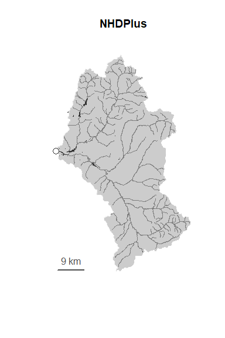

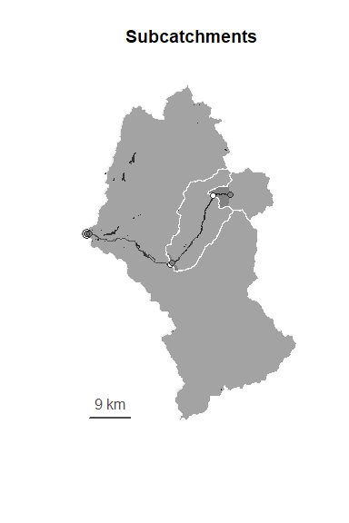

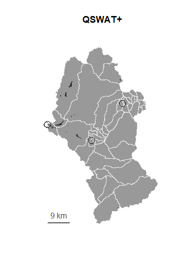

Figure 1. Three models of the Lamar River: from NHDPlus (left), rswat.maker (middle), and QSWAT+ (right).

The final output is a set of three SWAT+ models and a parent QSWAT+ project for each one (plotted in Figure 1, right), all linked together at the circled gage sites. By default the package looks for gages with service records on the [National Water Information System](https://waterservices.usgs.gov) (NWIS) of the USGS, and it will maintain a copy of current and historical NWIS flow data on your local machine.

All of the intermediate steps in an `rswat.maker` project are individually documented and reproducible, and all source data are cached prior to transformation. This is similar in spirit to the (currently inactive) *SWAT+ AW* project by Chawanda et al. (2020), whose functionality is emulated by the last three steps of `rswat.maker` (in subsections 7, 8, and 9)

## Getting started

Every `rswat.maker` project starts with a main outlet location. In principle this can be at any position along any major channel in the continental USA, but we recommend setting it at/near the site of a stream gage listed on NWIS.

For example, just above the outlet of the Lamar, at its confluence with the Upper Yellowstone River, there is an active USGS stream gage reporting daily flow values. This is indicated by the large white circle in Figure 1 (left). We set its (WGS84) coordinates in R like so:

```r
outlet = c(-110.0018722, 45.00283056) |> sf::st_point() |> sf::st_sfc(crs=4326)
```

The easiest way to browse for site coordinates is using the USGS [National Water Dashboard](https://dashboard.waterdata.usgs.gov) web app with the “Hydrology > Watersheds” layer visible. Look for gages with daily discharge records in suitably small watersheds. When you have found your site, go to its metadata section and copy the coordinates.

## The whole workflow

With the outlet positioned we are now ready to generate SWAT+ projects. For a completely automated workflow, pass the outlet along with a storage path to the function `run_maker`.

```r
run_maker(lamar_dir, outlet=outlet, overwrite=TRUE)
```

This path becomes the root of a directory tree where the function writes all of its output in sequence. The whole process is illustrated in the flow chart below, where the steps are grouped into four phases for simplicity:

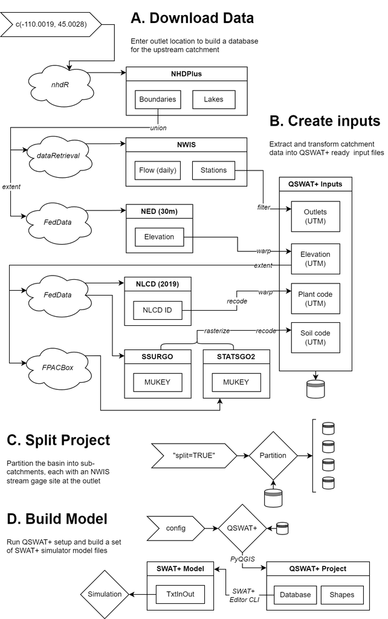

Figure 2. A flow chart for `rswat.maker` splits the whole process into four phases

Run a single step by setting `what` to its name (see `?run_maker` for the list of step names). Those not interested in SWAT+ can also set the keyword `what='data'`, which runs only Phase “A” in Figure 2.

This is a lot to take in all at once. However, `run_maker` is just a wrapper for a series of helper function calls that run the individual steps. So instead of showing all of the console output at once, we will go through it step-by-step, and show how the individual helper functions work.

# Data

The first five steps in `rswat.maker` are for fetching the data required to set up QSWAT+.

## 1. NHDPlus catchment model (`get_catch`)

To narrow its search for hydrology data `run_maker` first needs a spatial extent for the catchment. But all we have at the beginning is a point - the outlet. The catchment boundary *could* be derived from a DEM (and QSWAT+ will do so later) but this is tricky without knowing the approximate extent ahead of time.

Instead, we get our initial model from the [National Hydrography Dataset Plus](https://doi.org/10.3133/fs20203033) (NHDPlus), which offers a nation-wide collection of catchment data at moderate resolution (Viger et al. 2016). The helper function `get_catch` uses the [`nhdR`](https://cran.r-project.org/package=nhdR) package to query this database, and returns a subset of the NHDPlus data relevant to your catchment, along with a catchment boundary.

```r
catch_list = get_catch(outlet)
```

[output not shown]

The output `catch_list` is a list of watershed features. Save it with `save_catch`, reload it with `open_catch`, and visualize it with `plot_catch`. For example the left panel of Figure 1, which shows the catchment, streams, and lakes, was generated by this simple function call

```r
plot_catch(lamar_dir, main='NHDPlus')
```

To get a list of file paths written in this step, call `save_catch` with default argument `overwrite=FALSE`

```r
save_catch(lamar_dir)
```

```
#>                                                     edge
#>          "D:/rswat_data/lamar_contemporary/nhd/edge.csv"
#>                                                   outlet
#>    "D:/rswat_data/lamar_contemporary/nhd/outlet.geojson"
#>                                                catchment
#> "D:/rswat_data/lamar_contemporary/nhd/catchment.geojson"
#>                                                     flow
#>      "D:/rswat_data/lamar_contemporary/nhd/flow.geojson"
#>                                                     lake
#>      "D:/rswat_data/lamar_contemporary/nhd/lake.geojson"
#>                                                 boundary
#>  "D:/rswat_data/lamar_contemporary/nhd/boundary.geojson"
```

All of the `get_.` functions in the `rswat_maker` package have a corresponding `save_.` function that works this way. Similarly, calling `run_maker` with `overwrite=FALSE` returns a (long) list of all the destination paths for a project.

## 2. NWIS gage data (`get_nwis`)

`get_nwis` uses the [`dataRetrieval`](https://cran.r-project.org/package=dataRetrieval) package (Hirsch and De Cicco 2015) to collect daily service records from NWIS stream gage sites in your catchment. By default this looks for the most common stream flow record type, parameter code `00060` (discharge in ft3/s).

For the Lamar example we set `from_initial` to filter to records extending into or beyond 2005. This is so that our stream flow record aligns with a pre-existing weather database from a related R package, [`wxArchive`](https://github.com/deankoch/wxArchive). Users fetch all the available time periods by leaving `from_initial` at its default (`NULL`).

```r
nwis_points = get_nwis(lamar_dir, from_initial=as.Date('2005-01-01'))
```

```
#> requesting service records from NWIS
#> aggregating service records
#> found 7 station sites
#> 5 station(s) in catchment reporting flow_ft
#> filtering to 3 of 5 sites with records on/after 2005-01-01
```

The result is a data frame of point geometries with metadata about each site. The locations of the three stations found here are drawn as small grey circles in Figure 1 (middle).

After saving the point data with `save_nwis`, run `update_nwis` to download up-to-date service records and write them to disk.

```r
update_nwis(data_dir, overwrite=TRUE)
```

```
#> updating site 06187915 (1 of 3)
#> processing 1 record(s) at Soda Butte Cr at Park Bndry at Silver Gate (06187915)
#> NWIS reports 9055 observation(s) of dv-00060
#> 6771 day(s) downloaded
#>
#> updating site 06187950 (2 of 3)
#> processing 1 record(s) at Soda Butte Cr nr Lamar Ranger Station YNP (06187950)
#> NWIS reports 7265 observation(s) of dv-00060
#> 1360 day(s) downloaded
#>
#> updating site 06188000 (3 of 3)
#> processing 1 record(s) at Lamar River nr Tower Ranger Station YNP (06188000)
#> NWIS reports 29991 observation(s) of dv-00060
#> 6694 day(s) downloaded
#>
#> up to date
#> done
```

Subsequent calls to `update_nwis` will only request and append days not found there already.

For example, our main outlet, “Lamar River nr Tower Ranger Station YNP”, has site code `"06188000"`. Pass this to `load_nwis` and plot the result to get a hydrograph for the outlet running up to present day. Notice the extreme discharge rates during the spring of 2022, when a major flood event hit Yellowstone National Park.

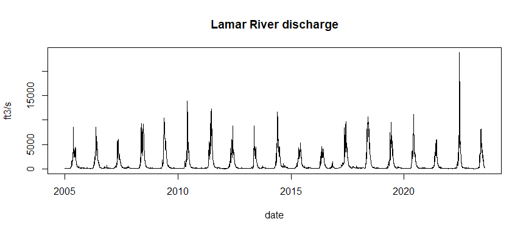

Figure 3. Hydrograph of stream flow from the Lamar River basin, measured near Tower Ranger Station

```r
flow = load_nwis("06188000", data_dir=lamar_dir, output='values')
plot(value~date, data=flow, type='l', xlab='date', ylab='ft3/s', main='Lamar River discharge')
```

The helper function call in this step, and the ones that follow, has first argument `data_dir` rather than `outlet` - the opposite of `get_catch` in the first step. This is because `get_nwis` relies on derived information that was saved to disk earlier on (the catchment boundary). In later steps, we will need both the NHDPlus information and the NWIS station locations. Order matters for most steps in this workflow.

## 3. DEM (`get_dem`)

Next, `run_maker` prepares an elevation model. Again the area of interest is determined from the NHDPlus boundary, except with some added padding around the edges to allow for possible imprecision (cropping to an imprecise boundary can cause issues in QSWAT+). `get_dem` then uses the [`FedData`](https://cran.r-project.org/package=FedData) package to fetch and merge the relevant tiles from the [USGS National Elevation Dataset](https://nationalmap.gov) (NED) (Gesch et al. 2009).

```r
dem = get_dem(lamar_dir)
```

```
#> Area of interest includes 4 NED tiles.
#> (Down)Loading NED tile for 45N and 110W.
#> (Down)Loading NED tile for 46N and 110W.
#> (Down)Loading NED tile for 45N and 111W.
#> (Down)Loading NED tile for 46N and 111W.
#> Mosaicking NED tiles.
```

Write the result to disk with `save_dem`. This saves both a copy of the original mosaicked source raster, and another copy cropped to the area of interest after warping (via bilinear averaging with GDAL) to the Universal Transverse Mercator (UTM) coordinate system at 90 metre resolution. View this UTM version of the DEM with `plot_rast`.

```r
plot_rast(lamar_dir, what='dem')
```

```
#> Geometry set for 1 feature
#> Geometry type: POLYGON
#> Dimension:     XY
#> Bounding box:  xmin: 542849.3 ymin: 4929961 xmax: 597659.3 ymax: 5012221
#> Projected CRS: WGS 84 / UTM zone 12N
#> POLYGON ((542849.3 4929961, 597659.3 4929961, 5...
```

```
#> Geometry set for 1 feature
#> Geometry type: POLYGON
#> Dimension:     XY
#> Bounding box:  xmin: 547259.3 ymin: 4934371 xmax: 593159.3 ymax: 5007631
#> Projected CRS: WGS 84 / UTM zone 12N
#> POLYGON ((547259.3 4934371, 593159.3 4934371, 5...
```

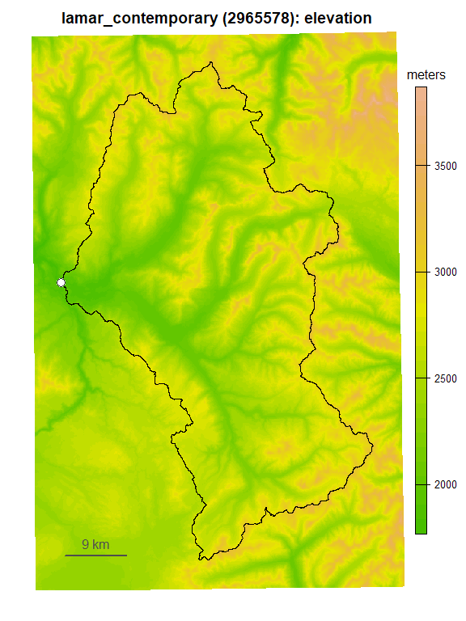

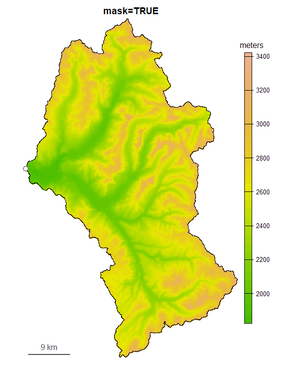

Figure 4. The National Elevation Dataset over the Lamar River basin with and without masking

```r
plot_rast(lamar_dir, what='dem', mask=TRUE, main='mask=TRUE')
```

Setting `mask=TRUE` will clip to the catchment boundary from NHDPlus in the plot for clarity of presentation, but will not affect the file on disk (masking is not recommended with QSWAT+).

Both `plot_rast` and `plot_catch` set default titles based on metadata from the project, as in Figure 4 (left). The number in parenthesis is the “COMID” key for the main outlet, which relates it to other objects in the NHDPlus model.

## 4. NLCD land use (`get_land`)

`get_land` uses the [`FedData`](https://cran.r-project.org/package=FedData) package to fetch a raster of land use classifications from the 2019 [National Land Cover Database](https://www.mrlc.gov) (NLCD) of the USGS (Homer et al. 2012). These categories either indicate the dominant plant community or else give a reason why there isn’t one (barren rock, water body, developed land, *etc*)

```r
land = get_land(lamar_dir)
```

```
#> running FedData::get_nlcd
#> copying raster data to RAM
#> projecting to UTM (GDAL warp)
```

In this step and the next, `rswat.maker` transforms the data to lie on the same UTM grid as the DEM. This ensures that the outputs from all three raster steps (3-5) share a common coordinate system and layout. As before, there is a helper function, `save_land` that writes the source raster and the derived (UTM) version. Call `plot_rast` to display the UTM version

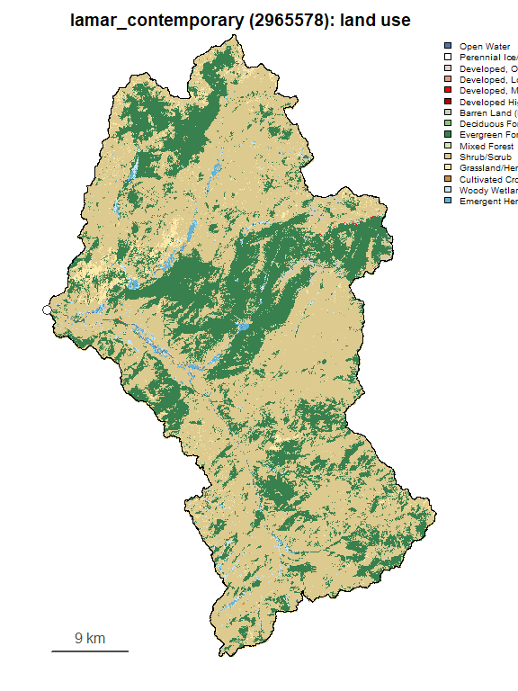

Figure 6. The National Land Cover Database over the Lamar River basin

```
#> Geometry set for 1 feature
#> Geometry type: POLYGON
#> Dimension:     XY
#> Bounding box:  xmin: 547259.3 ymin: 4934371 xmax: 593159.3 ymax: 5007631
#> Projected CRS: WGS 84 / UTM zone 12N
#> POLYGON ((547259.3 4934371, 593159.3 4934371, 5...
```

```r
plot_rast(lamar_dir, what='land', mask=TRUE)
```

## 5. STATSGO2/SSURGO soil (`get_soil`)

The process for soil data is similar to the land use step except that we use two source databases: the older and less detailed STATSGO2, and SSURGO, its modernized successor. Read more about them both at the USDA’s [website](https://websoilsurvey.sc.egov.usda.gov).

At the time of writing the coverage of SSURGO is patchy compared to STATSGO2, but when SSURGO is available it is expected to produce better a hydrological model (Wang and Melesse 2006). So we fill holes in the former with data from the latter. `get_soil` does this automatically after downloading copies of both. The call goes like this

```r
soil = get_soil(lamar_dir)
```

```
#> bounding box overlapped with 2 state(s) (MT, WY)
#> fetching data for Montana
#> fetching data for Wyoming
#> rasterizing MUKEYs for statsgo
#> fetching soil survey area keys
#> loading soilsa_a_nrcs.dbf and filtering to area of interest
#> loading SSURGO data from 5 soil survey area(s)...
#> (Down)Loading SSURGO data for survey area MT623
#> (Down)Loading SSURGO data for survey area MT640
#> (Down)Loading SSURGO data for survey area MT642
#> (Down)Loading SSURGO data for survey area WY656
#> (Down)Loading SSURGO data for survey area WY665
#> processing MUKEYs in 5 soil survey area(s)
#> rasterizing MUKEYs for ssurgo
#> opening STATSGO2 and SSURGO layers
#> merging
#> projecting to UTM (GDAL warp)
```

We edited out some lines from the console output above (output progress bars and URLs) to keep it short, but the story is the same. `get_soil` downloads the STATSGO2 polygons by by state from static URLs, then uses the `FedData` to fetch the relevant pieces of SSURGO’s much larger and more complex polygon database. Finally, the function rasterizes the SSURGO polygons to the DEM grid, and replaces any `NA` values (or MUKEYs that are absent from the SWAT+ database) with the STATSGO2 value at that location.

Once again we have a helper function, `save_soil`, to write the source data, along with their rasterized (UTM) versions, and the final merged product. Call `plot_rast` to display the latter.

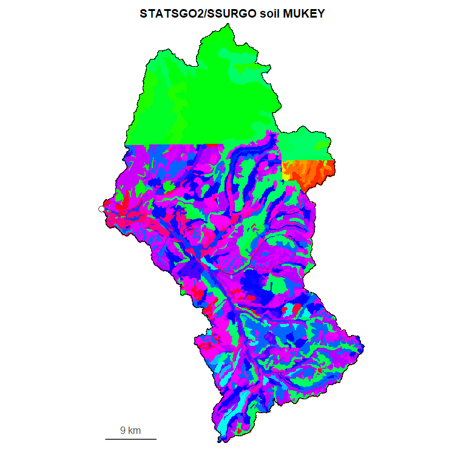

Figure 7. STATSGO2/SSURGO soil map unit keys (MUKEYS) over the Lamar River basin

```
#> Geometry set for 1 feature
#> Geometry type: POLYGON
#> Dimension:     XY
#> Bounding box:  xmin: 547259.3 ymin: 4934371 xmax: 593159.3 ymax: 5007631
#> Projected CRS: WGS 84 / UTM zone 12N
#> POLYGON ((547259.3 4934371, 593159.3 4934371, 5...
```

```r
plot_rast(lamar_dir, what='soil', main='STATSGO2/SSURGO soil MUKEY', mask=TRUE)
```

The colors here serve only to distinguish adjacent polygons, so there is no legend. The soil attributes themselves can found in a separate tabular database (indexed by MUKEY), that is distributed by the SWAT+ development team. This is already included in the SWAT+ installer bundle, so we there is no need to download it separately.

This is the end of the data retrieval phase of the workflow. All the pieces needed for QSWAT+ have been collected. Now on to processing.

# Processing

QSWAT+ constructs a SWAT+ model by splitting the basin into subbasins, all linked together by a stream network. At the shared outlet of these streams is a real-life gage with discharge data. Since all of the subbasins contribute to discharge at the outlet, this one hydrograph signal can be used to fit all subbasin parameters at once. For example with the Lamar River, we could use the hydrograph in Figure 3.

However, this approach leads to problems with model-fitting when the basin is complex. `get_split` helps avoid these problems by preemptively splitting a basin with multiple gages into subcatchments, so that the resulting SWAT+ models are individually less complex.

## 6. Subcatchments (`get_split`)

It is up to the modeller to decide how many subbasins to set in SWAT+; *ie* how detailed to make the jigsaw puzzle that forms the whole basin. The more we subdivide, the more we achieve realism. But this comes at a cost. Too many subbasins and the model becomes insensitive to their individual contributions. Too many parameters, and we risk overfitting, non-identifiability, and long compute times.

One way to balance this complexity trade-off is by splitting the problem into smaller, more manageable pieces. The goal with `get_split` is to use all the hydrographs at our disposal, while also minimizing the number of unknown parameters fitted to any one of them.

### Splitting at gages

`get_split` partitions an NHDPlus catchment into *subcatchments*, one per NWIS gage site. This site is always positioned at/near the outlet of the subcatchment. In cases where one subcatchment drains into another one, the outlet of the first becomes an inlet of the second. This is done automatically, similar to the “delineation” step in QSWAT+

We have three gage sites in the Lamar basin - one at the main outlet and two more on Soda Butte Creek. So, in this example, `get_split` produces a list of three subcatchment datasets

```r
split_result = get_split(lamar_dir)
```

```
#> loading gage points in D:/rswat_data/lamar_contemporary/nwis/flow_ft/station.geojson
#> computing catchment areas for 4 input gage locations
#> resolving stream order for 4 COMIDs
#> removed 1 duplicate station site(s) from outlet list
#> clipping catchment polygons to form 3 sub-catchments
#> collecting sub-catchment features
#> copying sub-catchment 1/3 : soda butte cr at park bndry at silver gate
#> copying sub-catchment 2/3 : lamar river nr tower ranger station ynp
#> copying sub-catchment 3/3 : soda butte cr nr lamar ranger station ynp
```

Call `save_split` with `overwrite=TRUE` to write the data to disk. This makes a new subdirectory for each subcatchment, each having (largely) the same file structure as the root directory. Visualize a subcatchment by passing one of these subdirectory paths to `plot_catch` or `plot_rast` in place of `lamar_dir`

```r
# subcatchment paths
sub_dir = save_split(lamar_dir)[['sub']]
print(sub_dir)
```

```
#> [1] "D:/rswat_data/lamar_contemporary/split/lamar_river_nr_tower_ranger_station_ynp"
#> [2] "D:/rswat_data/lamar_contemporary/split/soda_butte_cr_at_park_bndry_at_silver_gate"
#> [3] "D:/rswat_data/lamar_contemporary/split/soda_butte_cr_nr_lamar_ranger_station_ynp"
```

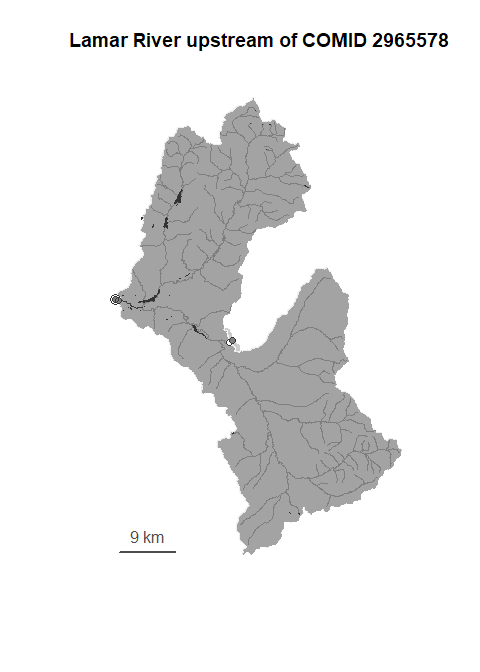

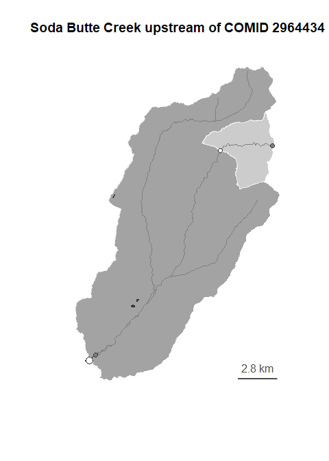

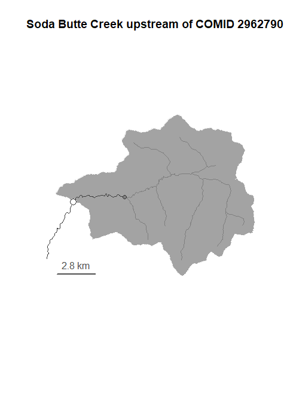

Figure 8. Subcatchments of the Lamar River, linked at NHPlus outlets (white circles)

```r
# reordered for presentation
for(d in sub_dir[c(1,3,2)]) plot_catch(d)
```

To get a basin-level view of how the pieces fit together, pass the basin-level directory (in our case `lamar_dir`) to `plot_catch` along with argument `sub=TRUE`. For example, we generated Figure 1 (middle) using this simple call

```r
plot_catch(lamar_dir, sub=TRUE, stream_col=NULL, main='Subcatchments')
```

With default arguments `plot_catch` draws grey circles for the actual gage sites and white circles for their snapped positions in NHDPlus.

This is about as precise as we can get with NHDPlus. For example the white and grey points in the Soda Butte Creek headwater (Figure 8, right) lie on the same COMID polygon, so under that model we cannot distinguish their catchments. While it may be obvious that the grey point drains a smaller area, it is not so obvious how to (accurately) revise the catchment boundary.

### Snapping and overlap

In the next step, QSWAT+ will delineate new boundaries (*subbasins*) where the gage sites more closely coincide with the outlets. However that involves a DEM covering, at minimum, the entire catchment. To help avoid accidentally masking part of the catchment, `get_split` snaps outwards to the nearest NHDPlus model boundaries and uses a buffer around the result when cropping rasters and geometries.

Subcatchments with inlets usually have some overlap with their upstream neighbour as a result of snapping. `plot_catch` draws this overlap with a different tone of fill colour to make it more obvious (as in Figure 8, middle).

Both `get_catch` and `open_catch` return two versions of the boundaries: one with and one without the overlap (an outer and inner boundary). The inner boundary forms the partition of the NHDPlus model, whereas the outer boundary defines the extent for QSWAT+ inputs.

At this stage we have all the information we need to run QSWAT+. What remains is to translate the data into a format that QSWAT+ can understand. This is the job of `save_qswat`.

## 7. QSWAT+ inputs (`save_qswat`)

In the following call we set `sub=TRUE` to loop over subcatchments and make QSWAT+ inputs for each of them. Leave `sub=FALSE` at its default to make a whole-basin project instead or to run the step for a single subcatchment.

```r
qswat_result = save_qswat(lamar_dir, sub=TRUE, overwrite=TRUE)
```

```
#> making QSWAT+ inputs...
#> writing inputs for 3 sub-catchments
#> done
```

Call `save_qswat` again, this time dropping the `overwrite=TRUE` argument, to get the paths written

```r
qswat_paths = save_qswat(lamar_dir, sub=TRUE)
qswat_paths |> head(1) |> print()
```

```
#> $lamar_river_nr_tower_ranger_station_ynp
#>                                                                                             outlet
#>  "D:/rswat_data/lamar_contemporary/split/lamar_river_nr_tower_ranger_station_ynp/qswat/outlet.shp"
#>                                                                                                dem
#>     "D:/rswat_data/lamar_contemporary/split/lamar_river_nr_tower_ranger_station_ynp/qswat/dem.tif"
#>                                                                                               soil
#>    "D:/rswat_data/lamar_contemporary/split/lamar_river_nr_tower_ranger_station_ynp/qswat/soil.tif"
#>                                                                                               land
#> "D:/rswat_data/lamar_contemporary/split/lamar_river_nr_tower_ranger_station_ynp/qswat/landuse.tif"
#>                                                                                        land_lookup
#> "D:/rswat_data/lamar_contemporary/split/lamar_river_nr_tower_ranger_station_ynp/qswat/landuse.csv"
```

These files require no further transformation for QSWAT+. They are already in the recommended projection (UTM), and `save_qswat` has formatted their contents using the expected encoding (for `NA` values, plant codes, MUKEYs, *etc*).

## 8. QSWAT+ setup (`run_qswat`)

At this stage we could leave the R environment and open QGIS to run QSWAT+ the normal way - with a cursor and a little patience. We recommend that users do so at least once, and that they familiarize themselves with QSWAT+ and its documentation before using the automation in `run_qswat`. If things go awry in `rswat.maker`, the interactive GUI in QGIS can often reveal the problem (*eg* a snapping issue) at a glance.

The QSWAT+ plugin is mature, well-documented, and it has a large and active user-base. However, there are serious drawbacks to using graphical interfaces (GUIs) for model-building: reproducibility becomes a challenge, and batch jobs become labour-intensive. `run_qswat` solves both problems at once.

### Automation with `run_qswat`

QSWAT+ is written in Python and runs in the PyQGIS3 environment (QGIS Development Team 2023), but users normally interact with it through the QGIS GUI. `run_qswat` provides an alternative way of using QSWAT+ that functions more like a command line interface (CLI). This is similar to the SWAT+ AW program (Chawanda et al. 2020), except based in R.

`run_qswat` manually assigns setup parameters (some defaults, some user-supplied, and some based on the input data) before calling the processing modules in the right order. It produces the same output as QSWAT+, including a working QGIS project file (.qgs) that can be opened for viewing after setup is complete.

Note that `run_qswat` wraps a batch file that looks for QGIS in `osgeo_dir`. This means the function is only available to Windows users with a QGIS installation, and if this is not in the usual location (see below), `osgeo_dir` must set manually. The example below shows how to run setup on the subcatchment in Figure 8 (middle).

```r
# default path to QGIS
osgeo_dir = 'C:/Program Files/QGIS 3.32.0'

# copy subcatchment paths and pick one
sub_dir = save_split(lamar_dir)[['sub']]
sub_dir_soda = sub_dir[3]

# run setup
qswat_result = run_qswat(sub_dir_soda, overwrite=TRUE, osgeo_dir=osgeo_dir)
```

```
#> running QSWAT+ to create project: soda_butte_cr_nr_lamar_ranger_station_ynp
#> running delineation checks
#> loading QSWAT+ model geometries from /qswat/soda_butte_cr_nr_lamar_ranger_station_ynp/Watershed/Shapes
#> outlet 0 moved 52 m in total
#> inlet 1 moved 14 m in total
#> QSWAT+ completed and passed checks
```

### QSWAT+ results

The console output above is deceptively short. Behind the scenes, `run_qswat` has:

- recorded a list of inputs
- launched an instance of QGIS (without the GUI) and loaded the plugin
- executed all QSWAT+ steps (delineation, HRUs, *etc*) and saved the results
- opened the resulting geometries and run sanity checks (see `?check_qswat`)
- written a log file

This process is easy to reproduce. As long as the inputs remain unchanged, you will get identical output from every call to `run_qswat`. Get the input and output file paths by calling `run_qswat` with (the default) `overwrite=FALSE`

```r
# get paths to outputs from QSWAT+ and rswat.maker
qswat_paths = run_qswat(sub_dir_soda)
qswat_paths |> names() |> print()
```

```
#> [1] "qswat"  "input"  "output" "log"
```

“input” is a JSON record of all inputs and parameters supplied to QSWAT+,

```r
# list all inputs
qswat_paths[['input']] |> readLines() |> jsonlite::fromJSON() |> names() |> print()
```

```
#>  [1] "info"              "name"              "dem"               "outlet"            "landuse_lookup"
#>  [6] "landuse"           "soil"              "lake_threshold"    "channel_threshold" "stream_threshold"
#> [11] "snap_threshold"
```

“log” contains (we hope) a string of messages from QSWAT+ about completed steps, as it does here,

```r
# read the last few lines of logfile
qswat_paths[['log']] |> readLines() |> tail() |> cat()
```

```
#> Writing aquifers and deep aquifers tables ... HRUs done: 359 HRUs formed with 229 channels in 13 subbasins.  writing D:/rswat_data/lamar_contemporary/split/soda_butte_cr_nr_lamar_ranger_station_ynp/qswat/qswat_output.json  >> finished running QSWAT+
```

“output” is another JSON record listing important project-related paths,

```r
qswat_paths[['output']] |> readLines() |> jsonlite::fromJSON() |> names() |> print()
```

```
#>  [1] "channel"       "stream"        "sub"           "outlet"        "lake"          "hru"
#>  [7] "lsu"           "hru_full"      "lsu_full"      "sql"           "txt"           "editor_exe"
#> [13] "simulator_dir"
```

and “qswat” points to the root directory of the whole QSWAT+ project.

View the geometries from the “output” list (ESRI shapefiles) by loading them `load_qswat`, or by plotting them directly with `plot_qswat`. For example, here are the NHDPlus and QSWAT+ models side by side for comparison

```
#> loading QSWAT+ model geometries from /qswat/soda_butte_cr_nr_lamar_ranger_station_ynp/Watershed/Shapes
```

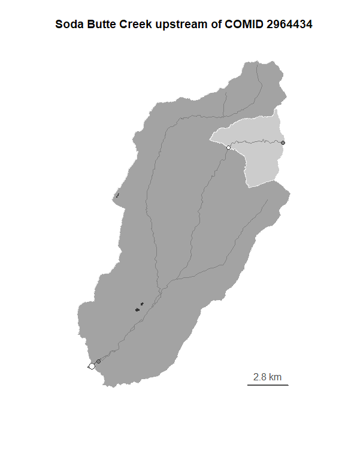

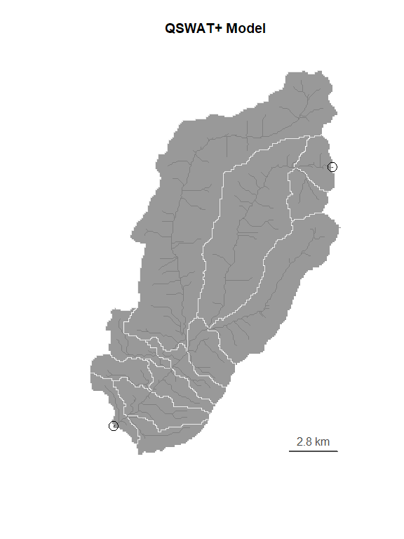

Figure 9. Two models of Soda Butte Creek subcatchment geometries: from NHDPlus (left) and QSWAT+ (right)

```r
sub_dir_soda |> plot_catch()
sub_dir_soda |> plot_qswat(main='QSWAT+ Model')
```

The channel geometry from QSWAT+ is far more detailed than NHDPlus in this example, but this can be adjusted via the threshold arguments in `run_qswat`. In general users can expect the QSWAT+ delineation output to slightly differ from (and improve on) the output from NHDPlus.

Outlets and inlets are identified in the QSWAT+ plot with large unfilled circles. Notice that the NHDPlus outlet is gone, and we have only the one point for the inlet, correctly positioned at its gage site.

Note also that `run_qswat` currently only supports the “Dominant HRU” method of delineating HRUs in QSWAT+. This assigns a set of parameters to each subbasin that is meant to be representative of all the landscape within it. The larger the subbasin, the more this becomes an abstraction that summarizing the overall behaviour of several qualitatively different landscape features.

## 9. SWAT+ Editor (`run_editor`)

QSWAT+ has produced an SQLite database, a set of geometries, and a QGIS project, but no SWAT+ configuration (config) files. The config files are what actually configure and initialize the SWAT+ simulator (whereas the QSWAT+ files provide context). The SWAT+ development team provides a standalone Python3-based GUI, [SWAT+ Editor](https://bitbucket.org/swatplus/swatplus.editor), for creating config files.

Users normally open SWAT+ Editor and point it to their project database (.sqlite) file, or else open the QSWAT+ project (.qgs) file in QGIS and use its interface. `run_editor` runs config file creation automatically, by making use of the SWAT+ Editor CLI for batch jobs (via `shell`).

Simply call `run_editor` after completing `run_qswat`

```r
editor_result = run_editor(sub_dir_soda, overwrite=TRUE)
```

```
#> running SWAT+ Editor to populate /qswat/soda_butte_cr_nr_lamar_ranger_station_ynp/Scenarios/Default/TxtInOut
```

This converts the SQLite database from the previous step (QSWAT+) into a set of several dozen config files in the “TxtInOut” subdirectory. It also optionally imports weather data from `weather_dir`, or else sets default weather station locations at the centroids of the subbasins (see `?run_editor` and `?make_weather`).

As with QSWAT+ setup, this step produces a log file

```r
# find output file paths and print contents
editor_paths = run_editor(sub_dir_soda)
editor_paths[['log']] |> readLines() |> tail() |> cat()
```

```
#>  {"percent": 116, "message": "Importing ru_yr.txt..."}  {"percent": 118, "message": "Importing ru_aa.txt..."}  Done.
```

```r
editor_paths[['txt']] |> list.files() |> head()
```

```
#> [1] "aqu_catunit.ele" "aqu_dr.swf"      "aquifer.aqu"     "aquifer.con"     "aquifer_aa.txt"
#> [6] "aquifer_yr.txt"
```

The files in “TxtInOut” should now be ready for the SWAT+ simulator. See our other R package, [`rswat`](https://github.com/deankoch/rswat), which allows users to explore these files and run simulations (and much more!) from within the R environment.

# Applications

The idea with `get_split` is to configure your subcatchments (in SWAT+) to accept inlet data instead of modelling the whole drainage upstream. This has several advantages, which we talk about below.

The main downside with splitting is that there is no ground water exchanged between subcatchments. Unlike surface water discharge, which can be linked to other models via inlets, there is currently no way of linking aquifers from separate SWAT+ models.

This may not matter, depending on the basin, the layout of gages, and the modelling goals. But if it does, one possible workaround would be to use an external ground water simulator that ignores subbasin boundaries, like *gwflow* (Bailey et al. 2020), or rather an extension of it that supports multiple concurrent SWAT+ surface water models.

## Subbasin layout

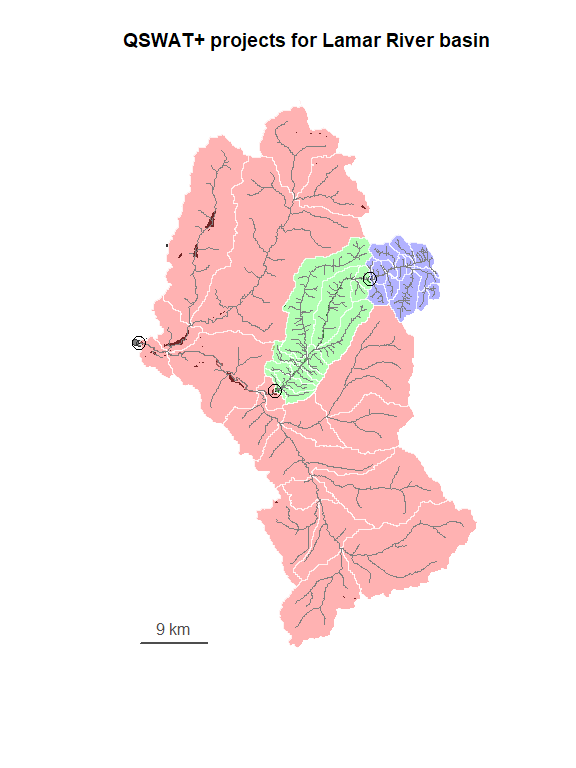

Figure 10. QSWAT+ models for three Lamar River subcatchments with NWIS gages at the circled sites

```r
# initialize mostly empty plot
plot_catch(lamar_dir,
           sub = TRUE,
           fill_col = 'white',
           stream_col = NULL,
           outlet_col = NULL,
           inlet_col = NULL,
           main = 'QSWAT+ projects for Lamar River basin')

# overlay QSWAT+ geometries
sub_dir = save_split(lamar_dir)[['sub']]
sub_dir[1] |> plot_qswat(fill_col=grDevices::adjustcolor('red', 0.3), quiet=TRUE, add=TRUE)
sub_dir[3] |> plot_qswat(fill_col=grDevices::adjustcolor('green', 0.3), quiet=TRUE, add=TRUE)
sub_dir[2] |> plot_qswat(fill_col=grDevices::adjustcolor('blue', 0.3), quiet=TRUE, add=TRUE)
```

Using the same ratio of subbasins per hydrograph on the main outlet catchment (in red), we wind up with less detail because the drainage is much larger. The main outlet hydrograph is the most difficult to fit (because of its large drainage), so a simpler model is better suited there. Upstream of it we leverage additional gage records to model a smaller area in detail.

The result is a more intentional and balanced model with respect to the observed data, and this makes model-fitting likelier to succeed.

## Divide and conquer

Splitting allows SWAT+ users to tackle larger basins and more complex arrangements of gages. For example we can easily create a project covering the whole Upper Yellowstone River basin, which drains the Lamar. The output of `get_split` for that project, with no restrictions on gage era, looks like this

```r
# print the subcatchment names
yellowstone_split = save_split(yellowstone_dir)
yellowstone_split[['sub']] |> basename() |> print()
```

```
#>  [1] "bear_creek_near_jardine_mt"                      "big_creek_near_emigrant_mt"
#>  [3] "blacktail_deer_creek_nr_mammoth_ynp"             "east_fork_blacktail_deer_creek_near_mammoth_ynp"
#>  [5] "gardner_river_near_mammoth_ynp"                  "lamar_river_nr_tower_ranger_station_ynp"
#>  [7] "lupine_creek_near_mammoth_ynp"                   "mill_creek_near_pray_mt"
#>  [9] "soda_butte_cr_at_park_bndry_at_silver_gate"      "soda_butte_cr_nr_lamar_ranger_station_ynp"
#> [11] "soda_butte_creek_at_cooke_city_mt"               "soda_butte_creek_at_silver_gate_mt"
#> [13] "tower_creek_at_tower_falls_ynp"                  "yellowstone_river_at_corwin_springs_mt"
#> [15] "yellowstone_river_at_tower_junction_ynp"         "yellowstone_river_at_yellowstone_lk_outlet_ynp"
#> [17] "yellowstone_river_near_canyon_hotel_ynp"         "yellowstone_river_near_livingston_mt"
```

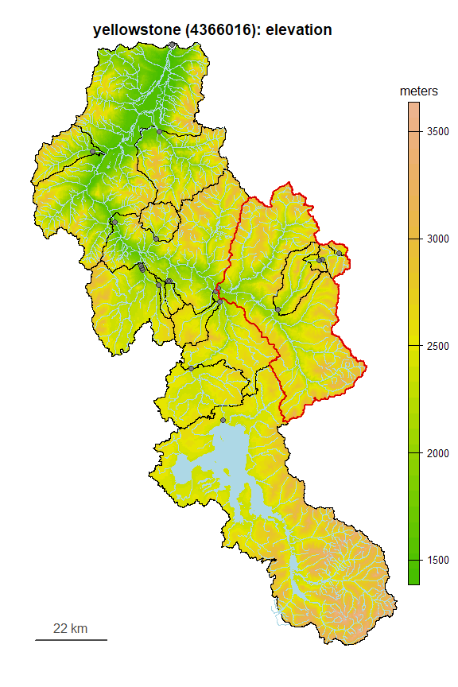

Figure 11. Subcatchments in the Upper Yellowstone River basin, with Lamar River basin highlighted in red

```r
# DEM base layer with subcatchments overlay
bbox_poly = yellowstone_dir |> plot_rast('dem', mask=TRUE)
boundary_poly = plot_catch(yellowstone_dir,
                           sub = TRUE,
                           stream_col = 'lightblue',
                           stem_col = 'lightblue',
                           lake_col = 'lightblue',
                           outlet_col= NULL,
                           inlet_col= NULL,
                           border_col = 'black',
                           fill_col = NULL,
                           add = TRUE)

# highlight Lamar basin
lamar_poly = open_catch(lamar_dir)[['boundary']] |> sf::st_transform(sf::st_crs(bbox_poly))
lamar_poly |> plot(border=grDevices::adjustcolor('red', 0.8), lwd=2, add=TRUE)
```

## Parallelization

This configuration of inlets and outlets in Figure 11 naturally leads to a subcatchment-level parallelization scheme: Headwater subcatchments can be simulated simultaneously as they are hydrologically decoupled. Descending downstream, and conveying simulated discharge values to inlets, we reach a second tier of subcatchment(s) where there is again no interdependence, so these too can be simulated simultaneously.

Iterating in this way until the main outlet, we divide a whole-basin simulation into a series of staged simulations at different subcatchment tiers, each running in parallel. This scheme was proposed and demonstrated in Cibin and Chaubey (2015) as part of their more general *Multi-Level Spatial Optimization* framework. `get_split` produces a set of catchment models compatible with that framework.

The scheme is illustrated for the Yellowstone project by the next code chunk, which colors the 18 subcatchments from Figure 11 according to the stage at which they would be simulated. To effect a parallelized simulation, users could replace the `plot_catch` call below with a call to the SWAT+ simulator followed by an update to any dependent inlet files (*eg* using `rswat`).

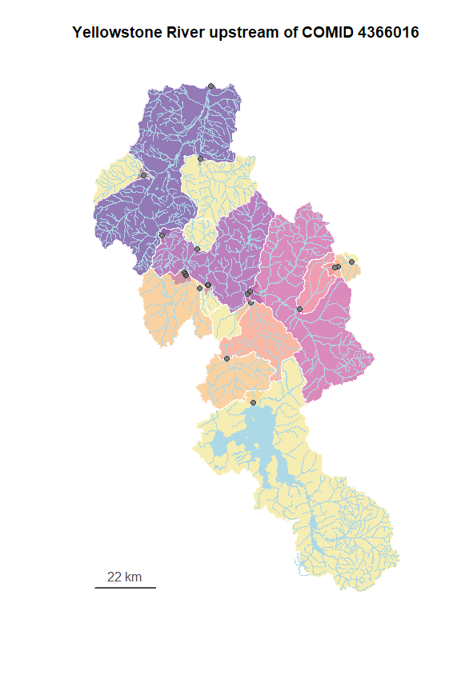

Figure 12. Subcatchments colored according to their order in a SWAT+ parallelization scheme

```r
# master gage locations data frame
gage = yellowstone_split[['gage']] |> sf::st_read(quiet=TRUE)

# initialize the plot
col_stage = grDevices::hcl.colors(7, pal='Sunset', rev=TRUE) |> adjustcolor(0.5)
boundary_poly = plot_catch(yellowstone_dir,
                           fill_col = NULL,
                           outlet_col = NULL,
                           inlet_col = NULL,
                           stem_col = NULL,
                           stream_col = NULL)

# iterate over subcatchment tiers
for(i in seq_along(col_stage)) {

  # directories to process (initially headwaters)
  head_name = gage |> dplyr::filter(headwater) |> dplyr::pull(dir_name)
  head_dir = file.path(yellowstone_dir, 'split', head_name) |> unique()

  # color the subcatchment(s)
  for(d in head_dir) plot_catch(d, add=TRUE,
                                outlet_col = NULL,
                                inlet_col = NULL,
                                stream_col = 'lightblue',
                                stem_col = 'lightblue',
                                lake_col = 'lightblue',
                                fill_col = col_stage[i])

  # flag the next tier as "headwater"
  i = i + 1
  gage = gage |>
    dplyr::filter(!headwater) |>
    dplyr::mutate(headwater = !(comid %in% downstream) )
}
```

In the Yellowstone example simulations would proceed in seven stages, corresponding to seven tiers in the routing network for the subcatchments. This is illustrated in Figure 12 as a series of darkening colours, from yellow to purple. In the first three stages (and particularly in the first), the simulator’s work is efficiently split into several parallelizable chunks.

# References

Bailey, Ryan T, Katrin Bieger, Jeffrey G Arnold, and David D Bosch. 2020. “A New Physically-Based Spatially-Distributed Groundwater Flow Module for SWAT+.” *Hydrology* 7 (4): 75.

Bieger, Katrin, Jeffrey G Arnold, Hendrik Rathjens, Michael J White, David D Bosch, Peter M Allen, Martin Volk, and Raghavan Srinivasan. 2017. “Introduction to SWAT+, a Completely Restructured Version of the Soil and Water Assessment Tool.” *JAWRA Journal of the American Water Resources Association* 53 (1): 115–30. https://doi.org/10.1111/1752-1688.12482.

Chawanda, Celray James, Chris George, Wim Thiery, Ann Van Griensven, Jaclyn Tech, Jeffrey Arnold, and Raghavan Srinivasan. 2020. “User-Friendly Workflows for Catchment Modelling: Towards Reproducible SWAT+ Model Studies.” *Environmental Modelling & Software* 134: 104812. https://doi.org/10.1016/j.envsoft.2020.104812.

Cibin, Raj, and Indrajeet Chaubey. 2015. “A Computationally Efficient Approach for Watershed Scale Spatial Optimization.” *Environmental Modelling & Software* 66: 1–11. https://doi.org/10.1016/j.envsoft.2014.12.014.

Eilander, Dirk, Hélène Boisgontier, Joost Buitink, Anaı̈s Couasnon, Brendan Dalmijn, Mark Hegnauer, Tjalling de Jong, et al. 2023. “HydroMT: Automated and Reproducible Model Building and Analysis.” *Journal of Open Source Software* 8 (83): 4897. https://doi.org/10.21105/joss.04897.

Gesch, Dean, Gayla Evans, James Mauck, John Hutchinson, William J Carswell Jr, et al. 2009. “The National Map—Elevation.” *US Geological Survey Fact Sheet* 3053 (4). https://doi.org/10.3133/fs20093053.

Hirsch, Robert M, and Laura A De Cicco. 2015. “User Guide to Exploration and Graphics for RivEr Trends (EGRET) and dataRetrieval: R Packages for Hydrologic Data.” US Geological Survey. https://doi.org/10.3133/tm4A10.

Homer, Collin H, Joyce A Fry, Christopher A Barnes, et al. 2012. “The National Land Cover Database.” *US Geological Survey Fact Sheet* 3020 (4): 1–4. https://doi.org/10.3133/fs20123020.

QGIS Development Team. 2023. *QGIS Geographic Information System*. QGIS Association. https://www.qgis.org.

Viger, Roland J, Alan Rea, Jeffrey D Simley, and Karen M Hanson. 2016. “NHDPlusHR: A National Geospatial Framework for Surface-Water Information.” *JAWRA Journal of the American Water Resources Association* 52 (4): 901–5. https://doi.org/10.1111/1752-1688.12429.

Wang, Xixi, and Assefa M Melesse. 2006. “Effects of Statsgo and Ssurgo as Inputs on Swat Model’s Snowmelt Simulation 1.” *JAWRA Journal of the American Water Resources Association* 42 (5): 1217–36. https://doi.org/10.1111/j.1752-1688.2006.tb05296.x.